# Metaanalysis in R

Metaanalysis is a form of bayesian hierarchical modelling.Lets explore

# correlations

compare with metafor(frequentist) and brms package(bayesian)

bayesian random effects have an advantage in rando effect models that they give probability distributions compared to frequentist point estimates.

http://www.metafor-project.org/doku.php/tips:rma_vs_lm_lme_lmer?s%5B%5D=lme4 https://mvuorre.github.io/post/2016/2016-09-29-bayesian-meta-analysis/

# Fixed-Effects Model

Let’s start with a fixed-effects model. As an example, consider the data from the meta-analysis by Molloy et al. (2014) on the relationship between conscientiousness and medication adherence. For each study, we can compute the r-to-z transformed correlation coefficient and corresponding sampling variance with:

```r
library(metafor)
library(lme4)
library(brms)
library(tidyverse)
data = dat.molloy2014 # correlation data set

dat <- escalc(measure="ZCOR", ri=ri, ni=ni, data=dat.molloy2014) # transforming correlation to yi(transformed correlation also called effect size) and vi( variance) akin to odds ratio/proportional log odds ratio in binary outcome and standard mean difference in continuous outcome, and standard error depending upon n(number) and r(correlation)

# escalc leads to calculation of yi(effect size) and vi(variance or standard error which is essential for metaanalysis)


# removing next five columns
dat[,-c(5:10)]
```

```
##                authors year  ni     ri      yi     vi
## 1      Axelsson et al. 2009 109  0.187  0.1892 0.0094
## 2      Axelsson et al. 2011 749  0.162  0.1634 0.0013
## 3         Bruce et al. 2010  55  0.340  0.3541 0.0192
## 4   Christensen et al. 1999 107  0.320  0.3316 0.0096
## 5  Christensen & Smith 1995  72  0.270  0.2769 0.0145
## 6         Cohen et al. 2004  65  0.000  0.0000 0.0161
## 7       Dobbels et al. 2005 174  0.175  0.1768 0.0058
## 8        Ediger et al. 2007 326  0.050  0.0500 0.0031
## 9         Insel et al. 2006  58  0.260  0.2661 0.0182
## 10       Jerant et al. 2011 771  0.010  0.0100 0.0013
## 11        Moran et al. 1997  56 -0.090 -0.0902 0.0189
## 12   O'Cleirigh et al. 2007  91  0.370  0.3884 0.0114
## 13       Penedo et al. 2003 116  0.000  0.0000 0.0088
## 14        Quine et al. 2012 537  0.150  0.1511 0.0019
## 15      Stilley et al. 2004 158  0.240  0.2448 0.0065
## 16 Wiebe & Christensen 1997  65  0.040  0.0400 0.0161
```

```r
# adding sei (standard error which is square root of variance

dat$sei = sqrt(dat$vi)

# changing name from  author to study

names(dat)[names(dat)=="authors"] <- "study"

dat
```

```
##                  study year  ni     ri controls          design
## 1      Axelsson et al. 2009 109  0.187     none cross-sectional
## 2      Axelsson et al. 2011 749  0.162     none cross-sectional
## 3         Bruce et al. 2010  55  0.340     none     prospective
## 4   Christensen et al. 1999 107  0.320     none cross-sectional
## 5  Christensen & Smith 1995  72  0.270     none     prospective
## 6         Cohen et al. 2004  65  0.000     none     prospective
## 7       Dobbels et al. 2005 174  0.175     none cross-sectional
## 8        Ediger et al. 2007 326  0.050 multiple     prospective
## 9         Insel et al. 2006  58  0.260     none     prospective
## 10       Jerant et al. 2011 771  0.010 multiple     prospective
## 11        Moran et al. 1997  56 -0.090 multiple     prospective
## 12   O'Cleirigh et al. 2007  91  0.370     none     prospective
## 13       Penedo et al. 2003 116  0.000     none cross-sectional
## 14        Quine et al. 2012 537  0.150     none     prospective
```

[output cut: 19 more lines]

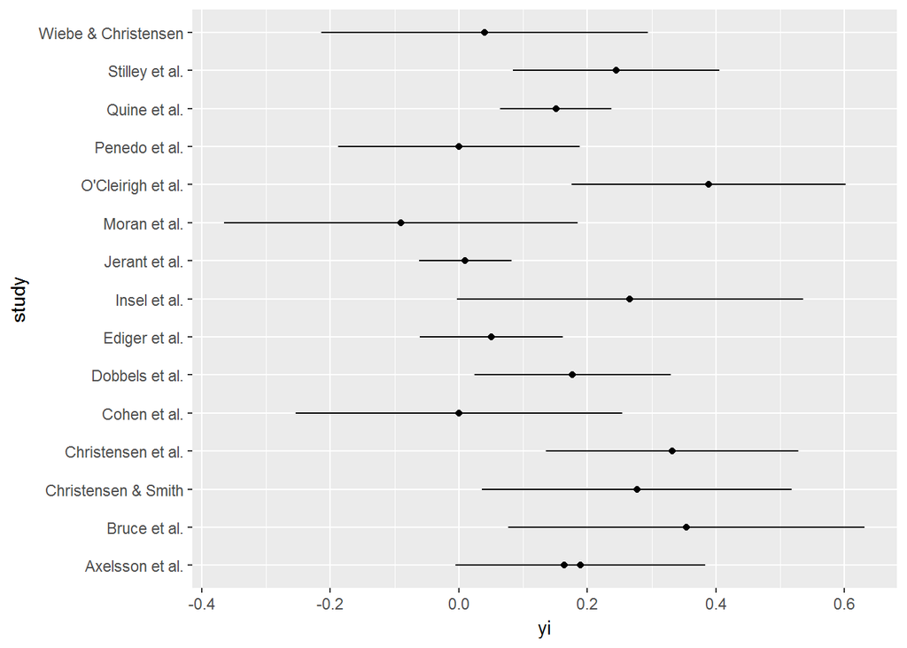

```r
# ggplot2 graphics of effect size and standard error to make forest plot
# see tthe us eof segment and limitation of axis here


ggplot(dat, aes(x=yi, y=study)) +
    geom_segment(aes(x = yi-sei*2, xend = yi+sei*2, y=study, yend=study)) +
    geom_point()
```

```r
# fixed effect


res.fe <- rma(yi, vi, data=dat, method="FE")
res.fe
```

```
##
## Fixed-Effects Model (k = 16)
##
## Test for Heterogeneity:
## Q(df = 15) = 38.1595, p-val = 0.0009
##
## Model Results:
##
## estimate       se     zval     pval    ci.lb    ci.ub
##   0.1252   0.0170   7.3642   <.0001   0.0919   0.1585      ***
##
## ---
## Signif. codes:  0 '***' 0.001 '**' 0.01 '*' 0.05 '.' 0.1 ' ' 1
```

```r
# Random effect
res.re <- rma(yi, vi, data=dat)
res.re
```

```
##
## Random-Effects Model (k = 16; tau^2 estimator: REML)
##
## tau^2 (estimated amount of total heterogeneity): 0.0081 (SE = 0.0055)
## tau (square root of estimated tau^2 value):      0.0901
## I^2 (total heterogeneity / total variability):   61.73%
## H^2 (total variability / sampling variability):  2.61
##
## Test for Heterogeneity:
## Q(df = 15) = 38.1595, p-val = 0.0009
##
## Model Results:
##
## estimate       se     zval     pval    ci.lb    ci.ub
##   0.1499   0.0316   4.7501   <.0001   0.0881   0.2118      ***
##
## ---
## Signif. codes:  0 '***' 0.001 '**' 0.01 '*' 0.05 '.' 0.1 ' ' 1
```

```r
# Default

ma_out <- rma(data = dat, yi = yi, sei = sei, slab = dat$study)
summary(ma_out)
```

```
##
## Random-Effects Model (k = 16; tau^2 estimator: REML)
##
##   logLik  deviance       AIC       BIC      AICc
##   8.6096  -17.2191  -13.2191  -11.8030  -12.2191
##
## tau^2 (estimated amount of total heterogeneity): 0.0081 (SE = 0.0055)
## tau (square root of estimated tau^2 value):      0.0901
## I^2 (total heterogeneity / total variability):   61.73%
## H^2 (total variability / sampling variability):  2.61
##
## Test for Heterogeneity:
## Q(df = 15) = 38.1595, p-val = 0.0009
##
## Model Results:
##
## estimate       se     zval     pval    ci.lb    ci.ub
##   0.1499   0.0316   4.7501   <.0001   0.0881   0.2118      ***
##
## ---
## Signif. codes:  0 '***' 0.001 '**' 0.01 '*' 0.05 '.' 0.1 ' ' 1
```

same model linear regression(lm)

```r
res.lm <- lm(yi ~ 1, weights = 1/vi, data=dat)
summary(res.lm)
```

```
##
## Call:
## lm(formula = yi ~ 1, data = dat, weights = 1/vi)
##
## Weighted Residuals:
##     Min      1Q  Median      3Q     Max
## -3.1919 -1.0719  0.6674  1.3173  2.4695
##
## Coefficients:
##             Estimate Std. Error t value Pr(>|t|)
## (Intercept)  0.12518    0.02711   4.617 0.000335 ***
## ---
## Signif. codes:  0 '***' 0.001 '**' 0.01 '*' 0.05 '.' 0.1 ' ' 1
##
## Residual standard error: 1.595 on 15 degrees of freedom
```

# Mixed effect fequentist models

nlme and lme4

```r
library(nlme)
dat$study <- 1:nrow(dat)
res.lme <- lme(yi ~ 1, random = ~ 1 | study, weights = varFixed(~ vi), data=dat)
summary(res.lme)
```

```
## Linear mixed-effects model fit by REML
##  Data: dat
##         AIC       BIC   logLik
##   -8.781569 -6.657418 7.390784
##
## Random effects:
##  Formula: ~1 | study
##         (Intercept) Residual
## StdDev:  0.06818354 1.259548
##
## Variance function:
##  Structure: fixed weights
##  Formula: ~vi
## Fixed effects: yi ~ 1
##                 Value  Std.Error DF  t-value p-value
## (Intercept) 0.1415557 0.03071906 16 4.608073   3e-04
##
## Standardized Within-Group Residuals:
##        Min         Q1        Med         Q3        Max
## -1.1596768 -0.6903414  0.1964221  0.7117538  1.4616798
##
## Number of Observations: 16
## Number of Groups: 16
```

lme4

```r
library(lme4)
res.lmer <- lmer(yi ~ 1 + (1 | study), weights = 1/vi, data=dat,
                 control=lmerControl(check.nobs.vs.nlev="ignore", check.nobs.vs.nRE="ignore"))
summary(res.lmer)
```

```
## Linear mixed model fit by REML ['lmerMod']
## Formula: yi ~ 1 + (1 | study)
##    Data: dat
## Weights: 1/vi
## Control:
## lmerControl(check.nobs.vs.nlev = "ignore", check.nobs.vs.nRE = "ignore")
##
## REML criterion at convergence: -14.8
##
## Scaled residuals:
##     Min      1Q  Median      3Q     Max
## -1.1597 -0.6903  0.1964  0.7117  1.4617
##
## Random effects:
##  Groups   Name        Variance Std.Dev.
##  study    (Intercept) 0.004649 0.06818
##  Residual             1.586461 1.25955
## Number of obs: 16, groups:  study, 16
##
## Fixed effects:
##             Estimate Std. Error t value
## (Intercept)  0.14156    0.03072   4.608
```

Note that some of the default checks need to be switched off before lmer() will go through with fitting this model.

A couple things are of note here:

```
The estimated intercept differs from the model coefficient obtained earlier with the rma() function.
The standard error is also different (and hence, the test statistic and p-value also differs).
The estimated standard deviation of the random effects also differs (0.0682 for lme() and lmer() compared to 0.0901 for rma()).
```

# Bayesian analysis of correlation

So far so good, we’re strictly in the realm of standard meta-analysis. But I would like to propose that instead of using custom meta-analysis software, we simply consider the above model as just another regression model, and fit it like we would any other (multilevel) regression model. That is, using Stan, usually through the brms interface. Going Bayesian allows us to assign prior distributions on the population-level parameters μ and τ

, and we would usually want to use some very mildly regularizing priors. Here, to make the results most comparable, I’ll use uniform (non-informative) priors:

μ∼U(−∞,∞)

and

τ∼U(0,1000)

```r
library(brms)
brm_out <- brm(yi | se(sei) ~ 1 + (1|study),
               prior = set_prior("uniform(0, 1000)", class = "sd"),
               data = dat, iter = 5000, warmup = 2000, cores = 4)
```

For example, what is the probability that the average effect size is greater than 0.2?

```r
avg_es <- as.data.frame(brm_out, pars = "b_")[,1]
cat( (sum(avg_es > 0.2) / length(avg_es))*100, "%")
```

```
## 7.816667 %
```

ggplot2 for beautiful forest plot

```r
# formatting data for ggplot
dat$authors = data$authors
dat
```

```
##    study year  ni     ri controls          design   a_measure c_measure
## 1      1 2009 109  0.187     none cross-sectional self-report     other
## 2      2 2011 749  0.162     none cross-sectional self-report       NEO
## 3      3 2010  55  0.340     none     prospective       other       NEO
## 4      4 1999 107  0.320     none cross-sectional self-report     other
## 5      5 1995  72  0.270     none     prospective       other       NEO
## 6      6 2004  65  0.000     none     prospective       other       NEO
## 7      7 2005 174  0.175     none cross-sectional self-report       NEO
## 8      8 2007 326  0.050 multiple     prospective self-report       NEO
## 9      9 2006  58  0.260     none     prospective       other     other
## 10    10 2011 771  0.010 multiple     prospective       other       NEO
## 11    11 1997  56 -0.090 multiple     prospective       other       NEO
## 12    12 2007  91  0.370     none     prospective self-report       NEO
## 13    13 2003 116  0.000     none cross-sectional self-report       NEO
## 14    14 2012 537  0.150     none     prospective self-report     other
```

[output cut: 19 more lines]

```r
# Drop columns by NULL
dat$label = NULL
dat = dat%>% select(yi,study,sei,authors)
```

```r
dat = rename(dat, label = authors)
```

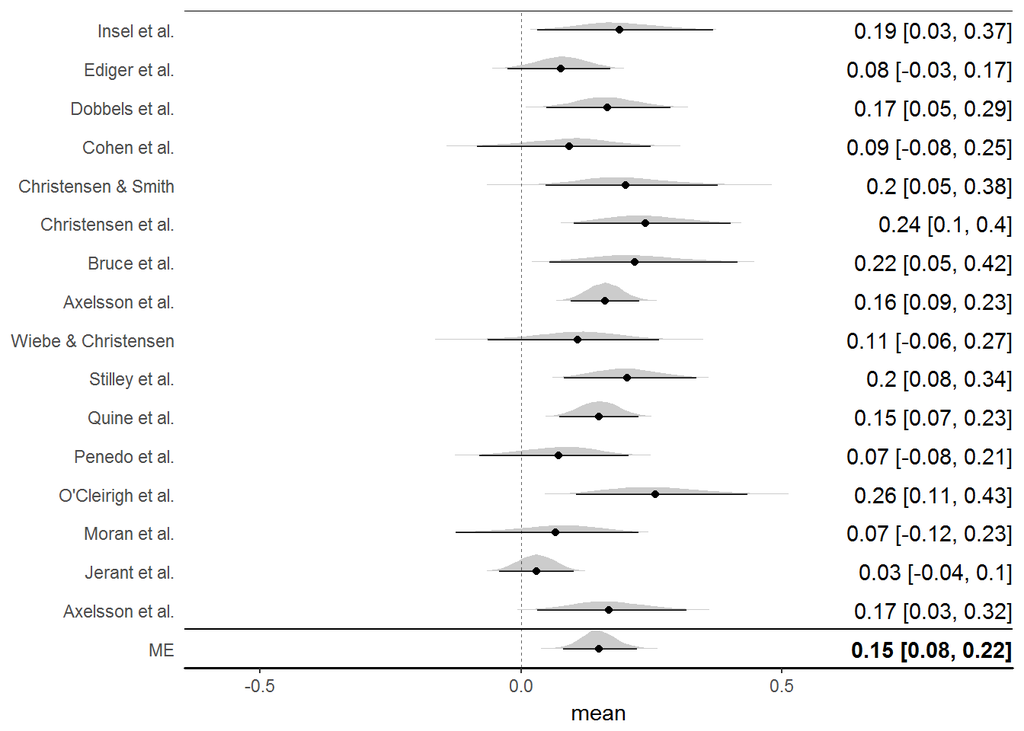

```r
devtools::install_github("mvuorre/vmisc")
library(vmisc)
brms_forest(data = dat, model = brm_out)
```

# Let us try with a standard mean difference , continuous data

Fit meta-analytic model with brms

Fitting the meta-analytic model is easy with brms! The formula specifies the study-specific effect size and standard error, an overall intercept (1), and the “random studies” ((1|study)). I’ll use four cores for speed and increase the adapt_delta parameter to avoid divergent transitions.

```r
library(metafor)
head(dat.bangertdrowns2004)
```

```
##   id   author year grade length minutes wic feedback info pers imag meta
## 1  1 Ashworth 1992     4     15      NA   1        1    1    1    0    1
## 2  2    Ayers 1993     2     10      NA   1       NA    1    1    1    0
## 3  3   Baisch 1990     2      2      NA   1        0    1    1    0    1
## 4  4    Baker 1994     4      9      10   1        1    1    0    0    0
## 5  5   Bauman 1992     1     14      10   1        1    1    1    0    1
## 6  6   Becker 1996     4      1      20   1        0    0    1    0    0
##         subject  ni    yi    vi
## 1       Nursing  60  0.65 0.070
## 2 Earth Science  34 -0.75 0.126
## 3          Math  95 -0.21 0.042
## 4       Algebra 209 -0.04 0.019
## 5          Math 182  0.23 0.022
## 6    Literature 462  0.03 0.009
```

```r
library(dplyr)
d <- dat.bangertdrowns2004 %>%
    mutate(label = paste0(author, " (", year, ")"), sei = sqrt(vi)) %>%
    select(study = id, label, yi, sei) %>%
    slice(1:15)
d
```

```
##    study              label    yi        sei
## 1      1    Ashworth (1992)  0.65 0.26457513
## 2      2       Ayers (1993) -0.75 0.35496479
## 3      3      Baisch (1990) -0.21 0.20493902
## 4      4       Baker (1994) -0.04 0.13784049
## 5      5      Bauman (1992)  0.23 0.14832397
## 6      6      Becker (1996)  0.03 0.09486833
## 7      7 Bell & Bell (1985)  0.26 0.32557641
## 8      8     Brodney (1994)  0.06 0.08366600
## 9      9      Burton (1986)  0.06 0.20000000
## 10    10   Davis, BH (1990)  0.12 0.22803509
## 11    11   Davis, JJ (1996)  0.77 0.32710854
## 12    12         Day (1994)  0.00 0.14491377
## 13    13     Dipillo (1994)  0.52 0.19235384
## 14    14     Ganguli (1989)  0.54 0.28809721
## 15    15  Giovinazzo (1996)  0.20 0.29325757
```

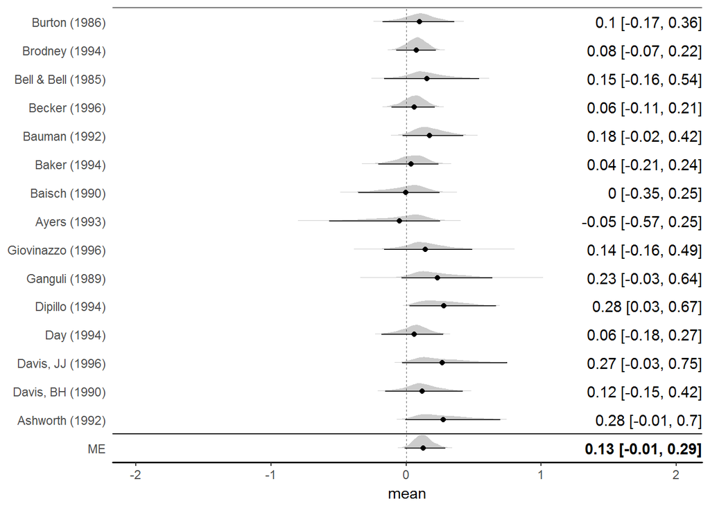

```r
mod <- brm(yi | se(sei) ~ 1 + (1|study), data = d,
           cores = 4, control= list(adapt_delta=.99) )
library(vmisc)
brms_forest(data = d, model = mod)
```

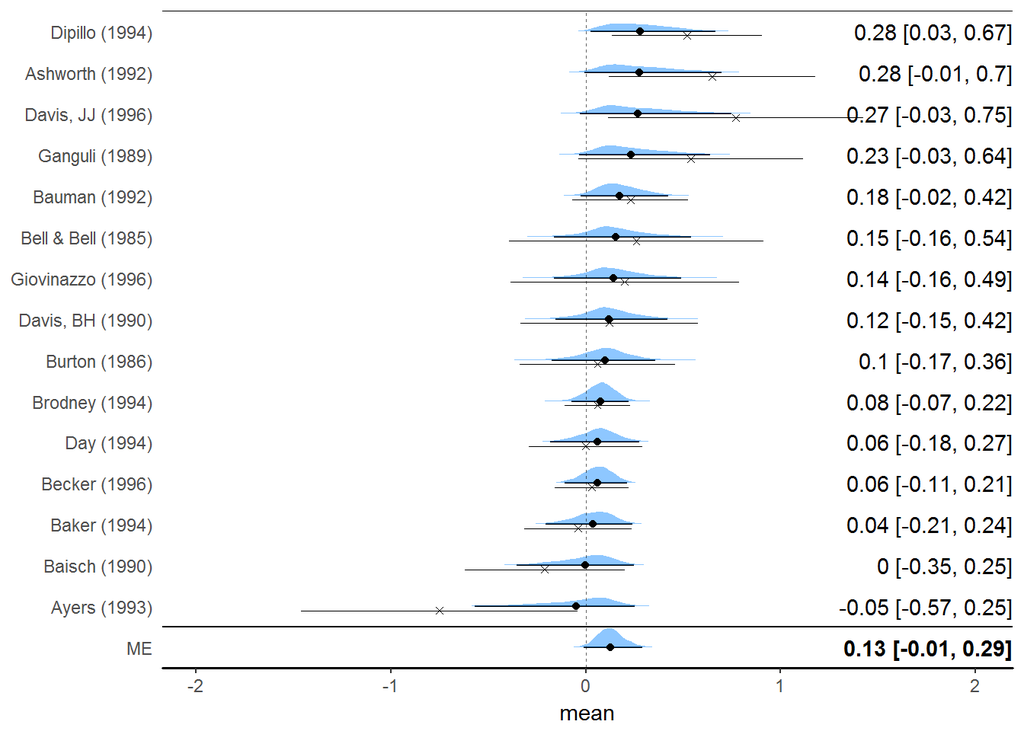

```r
brms_forest(
    data = d,
    model = mod,
    show_data = TRUE,  # Shows data means and SEs
    sort_estimates = TRUE,  # Sorts estimates based on their magnitude
    dens_fill = "dodgerblue")  # Fill densities with blue
```

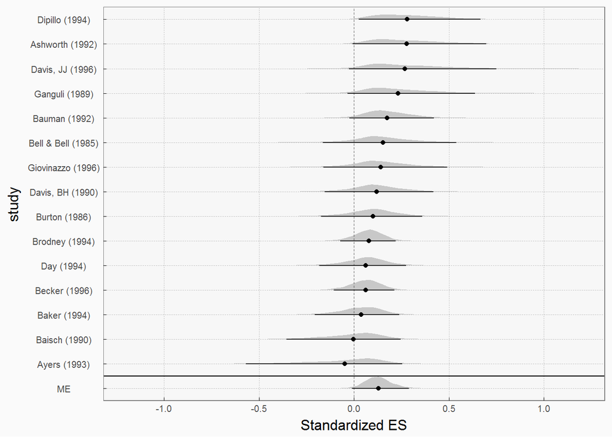

```r
library(ggplot2)
myplot <- brms_forest(data = d,
                      model = mod,
                      sort_estimates = TRUE)
myplot +
    scale_y_continuous("Standardized ES", limits = c(-1.2, 1.2)) +
    theme_blog()
```